# lab3

Kordell Schrock

9/25/2020

## Cleaning Data and Import of Packages

```r
library(readxl)
library(tidyverse)
```

```r
library(dplyr)
library(ggplot2)
library(devtools)
library(data.table)
library(plyr)
dat <- readxl::read_xls('../ds202_lab3/GSS.xls')
dat2 <-  readxl::read_xls('../ds202_lab3/GSS2.xls')
rename <- function(dat, oldnames, newnames) {
  datnames <- colnames(dat)
  datnames[which(datnames %in% oldnames)] <- newnames
  colnames(dat) <- datnames
  dat
}

dat <- rename(dat,c("Gss year for this respondent","Respondent id number", "Marital status", "Highest year of school completed" , "Political party affiliation", "General happiness", "Ballot used for interview"), c("year","id", "maritalStatus", "educationLevel", "politicalParty", "happiness", "ballot"))

dat2 <- rename(dat2,c("Gss year for this respondent","Respondent id number", "Marital status", "Age of respondent", "Highest year of school completed" , "Total family income","Political party affiliation", "General happiness", "Ballot used for interview"), c("year","id", "maritalStatus", "age", "educationLevel", "income" , "politicalParty", "happiness", "ballot"))
```

## Question 1 Find the average years of education for the respondents with each political party affiliation. Arrange your output in a meaningful order and print. Describe any patterns you find.

```r
dat$id <- as.numeric(as.character(dat$id))
dat$educationLevel <- as.numeric(as.character(dat$educationLevel))
Dontknow<- dat %>%
  filter(politicalParty == "Don't know" & educationLevel > 11   )

Indneardem<- dat %>%
  filter(politicalParty == "Ind,near dem" & educationLevel > 13 )

Indnearrep<- dat %>%
  filter(politicalParty == "Ind,near rep" & educationLevel > 13 )

Independent<- dat %>%
  filter(politicalParty == "Independent" & educationLevel > 12  )

Noanswer<- dat %>%
  filter(politicalParty == "No answer" & educationLevel > 12    )

Notstrdemocrat<- dat %>%
  filter(politicalParty == "Not str democrat" & educationLevel > 12 )

Notstrrepublican<- dat %>%
  filter(politicalParty == "Not str republican" & educationLevel > 13)

Otherparty<- dat %>%
  filter(politicalParty == "Other party" & educationLevel > 13)

Strongdemocrat<- dat %>%
  filter(politicalParty == "Strong democrat" & educationLevel > 12)

Strongrepublican<- dat %>%
  filter(politicalParty == "Strong republican" & educationLevel > 13)

mergeCols <- c("year", "id","maritalStatus", "educationLevel","politicalParty", "happiness","ballot")

averageEducationParty <- data.frame(aggregate(dat$educationLevel ~ dat$politicalParty, data=dat, median))

averageEducationPartySorted <- averageEducationParty[order(averageEducationParty$dat.educationLevel), ]


print(averageEducationPartySorted)
```

```
##    dat.politicalParty dat.educationLevel
## 1          Don't know                 11
## 4         Independent                 12
## 5           No answer                 12
## 6    Not str democrat                 12
## 9     Strong democrat                 12
## 2        Ind,near dem                 13
## 3        Ind,near rep                 13
## 7  Not str republican                 13
## 8         Other party                 13
## 10  Strong republican                 13
```

## Question 2 Create a single data frame containing records for the better educated respondents in each political party affiliation. A “better educated” respondent is someone who has strictly more years of education than the median in the same party affiliation. Print the structure of the data frame.

```r
dat$educationLevel <- as.numeric(as.character(dat$educationLevel))

filteredEducated <- do.call("rbind", list(Dontknow, Indneardem, Indnearrep, Independent, Noanswer, Notstrdemocrat, Notstrrepublican, Otherparty, Strongdemocrat, Strongrepublican))

head(filteredEducated)
```

```
## # A tibble: 6 x 7
##    year    id maritalStatus educationLevel politicalParty happiness   ballot
##   <dbl> <dbl> <chr>                  <dbl> <chr>          <chr>       <chr>
## 1  1974    33 Married                   12 Don't know     Very happy  Not appli…
## 2  1974   809 Married                   12 Don't know     Very happy  Not appli…
## 3  1974   995 Married                   12 Don't know     Pretty hap… Not appli…
## 4  1974  1474 Separated                 12 Don't know     Not too ha… Not appli…
## 5  2014     8 Married                   17 Don't know     Very happy  Ballot b
## 6  1972     1 Never married             16 Ind,near dem   Not too ha… Not appli…
```

### For Question 2. I filtered the Partys by median and only allowing people who are above their mean. As you look at the Dataframe the Political Party “Don’t Know”, their median is 11 so the New Dataframe should only have Education levels above 11 for the party “Don’t Know”, which is true for this Dataframe.

## Question 3 How is the happiness of a respondent related to his/her marriage status? Define that a person is happy if the response to question is “Very happy” or “Pretty happy”.

```r
happy<- dat %>%
  filter(happiness == "Very happy" | happiness == "Pretty happy")

happyFindings <- data.frame(aggregate(happy$happiness ~ happy$maritalStatus, data=happy, FUN = function(x){NROW(x)}))

print(happy)
```

```
## # A tibble: 52,386 x 7
##     year    id maritalStatus educationLevel politicalParty   happiness  ballot
##    <dbl> <dbl> <chr>                  <dbl> <chr>            <chr>      <chr>
##  1  1972     3 Married                   12 Independent      Pretty ha… Not app…
##  2  1972     5 Married                   12 Strong democrat  Pretty ha… Not app…
##  3  1972     6 Never married             14 Ind,near dem     Pretty ha… Not app…
##  4  1972     9 Never married             12 Strong democrat  Pretty ha… Not app…
##  5  1972    10 Married                   12 Strong democrat  Pretty ha… Not app…
##  6  1972    11 Married                   13 Strong democrat  Pretty ha… Not app…
##  7  1972    12 Married                    6 Not str republi… Pretty ha… Not app…
##  8  1972    13 Married                    9 Strong democrat  Pretty ha… Not app…
##  9  1972    15 Married                    9 Strong democrat  Very happy Not app…
## 10  1972    17 Married                   14 Ind,near rep     Very happy Not app…
## # … with 52,376 more rows
```

```r
print(happyFindings)
```

```
##   happy.maritalStatus happy.happiness
## 1            Divorced            6180
## 2             Married           29342
## 3       Never married           10686
## 4           No answer              16
## 5           Separated            1487
## 6             Widowed            4675
```

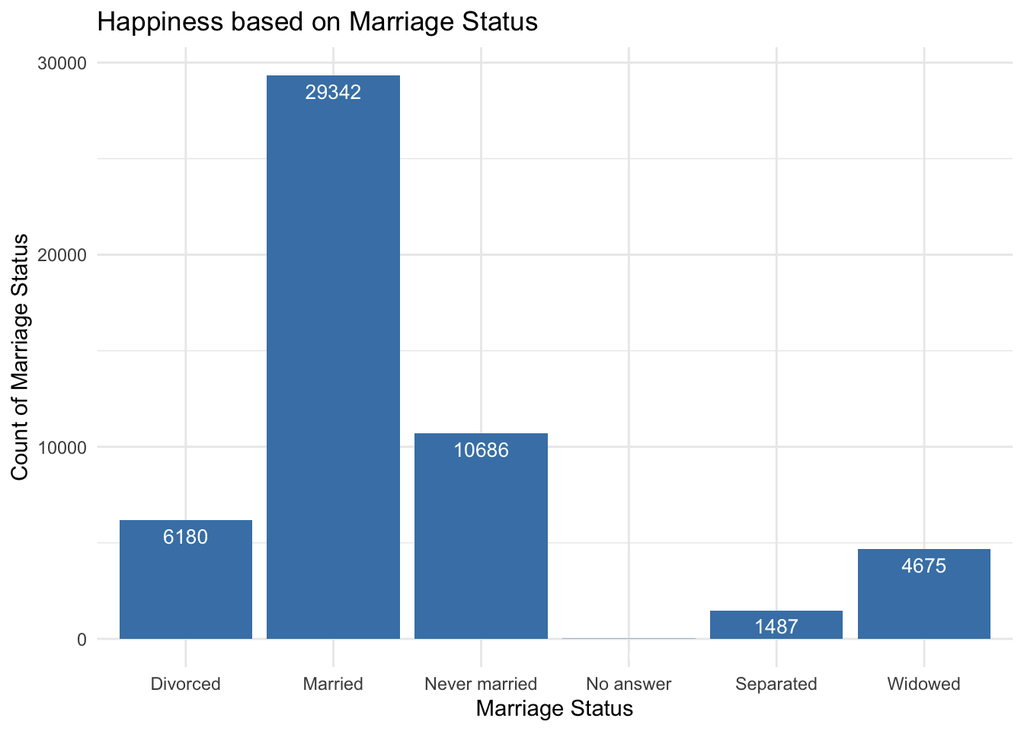

```r
ggplot(data=happyFindings, aes(x=happy.maritalStatus, y=happy.happiness)) +
  geom_bar(stat="identity", fill="steelblue",)+
  geom_text(aes(label=happy.happiness), vjust=1.6, color="white", size=3.5)+
  theme_minimal() + labs(title="Happiness based on Marriage Status", x ="Marriage Status", y= "Count of Marriage Status")
```

```r
nothappy<- dat %>%
  filter(happiness != "Very happy" & happiness != "Pretty happy")
# print(nothappy)

nothappinessFindings <- data.frame(aggregate(nothappy$happiness ~ nothappy$maritalStatus, data=nothappy, FUN = function(x){NROW(x)}))

print(nothappinessFindings)
```

```
##   nothappy.maritalStatus nothappy.happiness
## 1               Divorced               2199
## 2                Married               4787
## 3          Never married               3151
## 4              No answer                 11
## 5              Separated                755
## 6                Widowed               1525
```

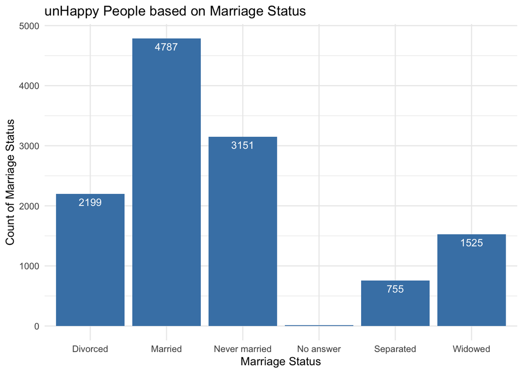

```r
ggplot(data=nothappinessFindings, aes(x=nothappy.maritalStatus, y=nothappy.happiness)) +
  geom_bar(stat="identity", fill="steelblue",)+
  geom_text(aes(label=nothappy.happiness), vjust=1.6, color="white", size=3.5)+
  theme_minimal() + labs(title="unHappy People based on Marriage Status", x ="Marriage Status", y= "Count of Marriage Status")
```

### For Question 3. I found that the most happy people are Married people with 29,342 in the DataSet. When looking at Sad People that are not happy I also found that Married people are the most sad too with 4,787.

## 4 Does party affiliation affect the relationship you found in the last question?

```r
happyPartyAffiliation<- data.frame(aggregate(happy$maritalStatus =="Married" ~ happy$politicalParty, data=happy, FUN = function(x){NROW(x)}))



happyPartyAffiliation <- rename(happyPartyAffiliation,c("happy.politicalParty","happy.maritalStatus.....Married."), c("politicalParty", "maritalStatus"))

print(happyPartyAffiliation)
```

```
##        politicalParty maritalStatus
## 1          Don't know             8
## 2        Ind,near dem          6248
## 3        Ind,near rep          4780
## 4         Independent          7541
## 5           No answer           293
## 6    Not str democrat         10804
## 7  Not str republican          8454
## 8         Other party           841
## 9     Strong democrat          8179
## 10  Strong republican          5238
```

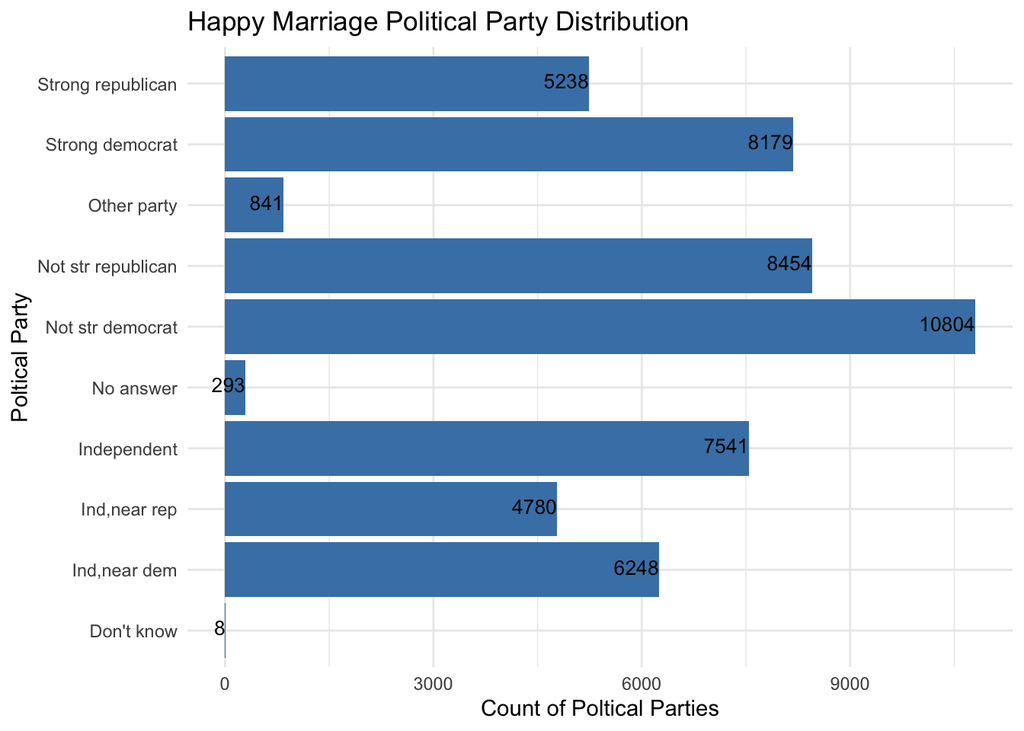

```r
ggplot(data=happyPartyAffiliation, aes(x=politicalParty, y=maritalStatus)) +
  geom_bar(stat="identity", fill="steelblue",)+
  geom_text(aes(label=maritalStatus), hjust=1, vjust=0.3, color="black", size=3.5)+
  theme_minimal() + labs(title="Happy Marriage Political Party Distribution", x ="Poltical Party", y= "Count of Poltical Parties") +coord_flip()
```

## 5 How is marrital status related to the education of a respondent? What are possible reasons accounting for the patterns you see?

```r
marriageEducationLevel<- data.frame(aggregate(dat$educationLevel ~ dat$maritalStatus, data=dat, median))

print(marriageEducationLevel)
```

```
##   dat.maritalStatus dat.educationLevel
## 1          Divorced                 13
## 2           Married                 12
## 3     Never married                 13
## 4         No answer                 16
## 5         Separated                 12
## 6           Widowed                 12
```

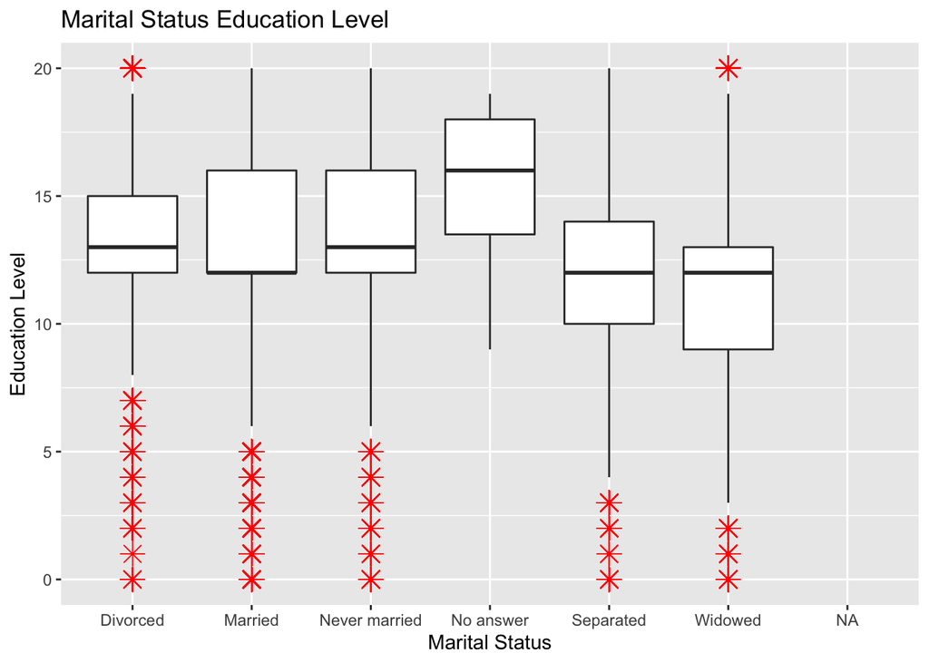

```r
# Change outlier, color, shape and size
ggplot(dat, aes(x=maritalStatus, y=educationLevel)) +
  geom_boxplot(outlier.colour="red", outlier.shape=8,
                outlier.size=4)+ labs(title="Marital Status Education Level", x ="Marital Status", y= "Education Level")
```

### For Question 5. When looking at the Marital Status for Median Education, we see that People who had No Answer had the highlest level of Education. For the most part Education levels was very close to each other looking at the BoxPlot. However, being Widowed had the lowest education level.

## 6 Explore two more interesting questions, and answer those questions using the GSS data.

## Question 6.1 does Happiness effect Education Level Have an effect?

```r
#1 does Happiness effect Education Level Have an effect?

happinessEducationFindings <- data.frame(aggregate(dat$educationLevel ~ dat$happiness, data=dat, median))



print(happinessEducationFindings)
```

```
##    dat.happiness dat.educationLevel
## 1     Don't know                 12
## 2      No answer                 12
## 3 Not applicable                 13
## 4  Not too happy                 12
## 5   Pretty happy                 12
## 6     Very happy                 12
```

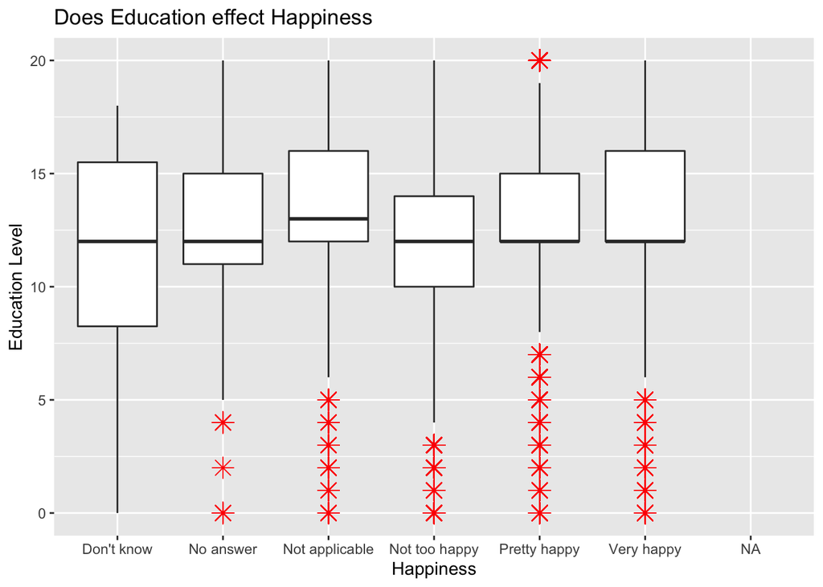

```r
ggplot(dat, aes(x=happiness, y=educationLevel)) +
  geom_boxplot(outlier.colour="red", outlier.shape=8,
                outlier.size=4)+ labs(title="Does Education effect Happiness ", x ="Happiness", y="Education Level")
```

```r
#2 Education Level based on Income. Why is $25000 or more has a higher median than others? Are they happy with more money?

dat2$educationLevel <- as.numeric(as.character(dat2$educationLevel))
educationByIncome <- data.frame(aggregate(dat2$educationLevel ~ dat2$income, data=dat2,na.rm=TRUE, na.action = na.omit, FUN= median))


educationByIncome<- dat2 %>%
  filter(income == "$25000 or more")

educationByAge2999 <- data.frame(aggregate(educationByIncome$educationLevel ~ educationByIncome$age, data=educationByIncome,  FUN = median))

happyByIncome2999 <- data.frame(aggregate(educationByIncome$educationLevel ~ educationByIncome$happiness, data=educationByIncome,  FUN = median))

print(educationByAge2999)
```

```
##    educationByIncome.age educationByIncome.educationLevel
## 1                     18                             11.0
## 2                     19                             12.0
## 3                     20                             12.0
## 4                     21                             13.0
## 5                     22                             13.0
## 6                     23                             14.0
## 7                     24                             13.0
## 8                     25                             14.0
## 9                     26                             14.0
## 10                    27                             14.0
## 11                    28                             14.0
## 12                    29                             14.0
## 13                    30                             14.0
## 14                    31                             14.0
```

[output cut: 59 more lines]

```r
print(happyByIncome2999)
```

```
##   educationByIncome.happiness educationByIncome.educationLevel
## 1                  Don't know                               16
## 2                   No answer                               14
## 3              Not applicable                               14
## 4               Not too happy                               13
## 5                Pretty happy                               14
## 6                  Very happy                               14
```

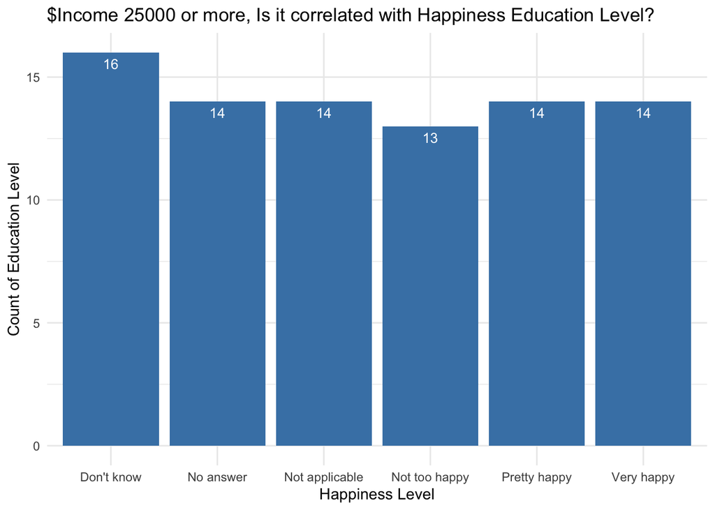

```r
happyByIncome2999 <- rename(happyByIncome2999,c("educationByIncome.happiness","educationByIncome.educationLevel"), c("happiness", "educationLevel"))

ggplot(data=happyByIncome2999, aes(x=happiness, y=educationLevel)) +
  geom_bar(stat="identity", fill="steelblue",)+
  geom_text(aes(label=educationLevel), vjust=1.6, color="white", size=3.5)+
  theme_minimal() + labs(title="$Income 25000 or more, Is it correlated with Happiness Education Level?", x ="Happiness Level", y= "Count of Education Level")
```

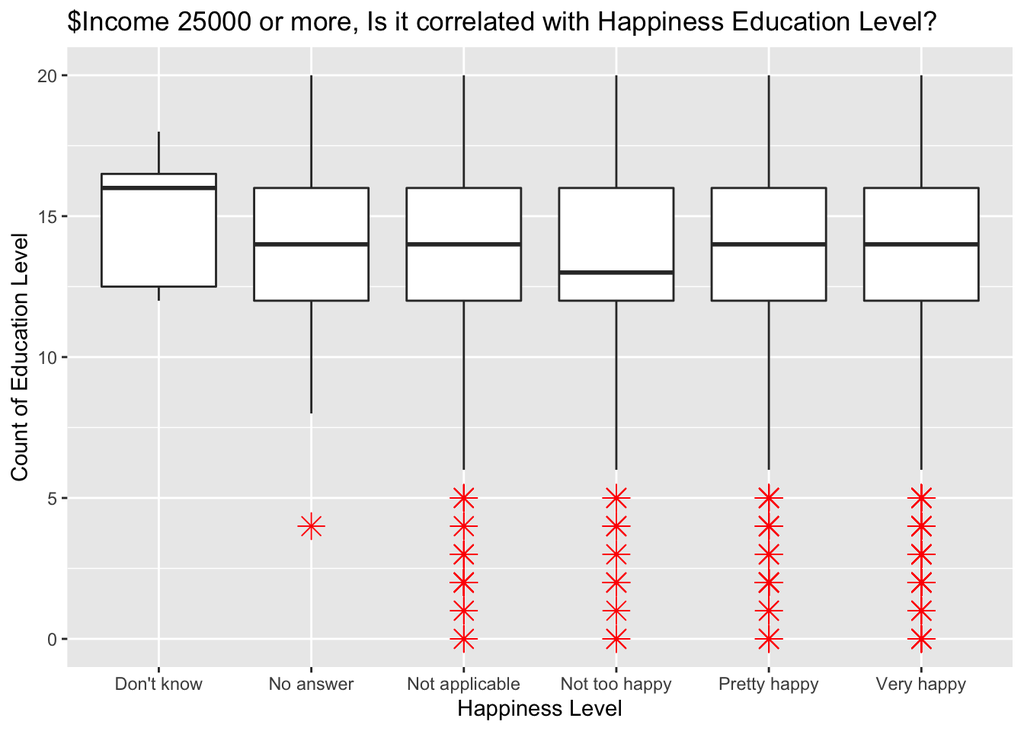

```r
ggplot(educationByIncome, aes(x=happiness, y=educationLevel)) +
  geom_boxplot(outlier.colour="red", outlier.shape=8,
                outlier.size=4)+ labs(title="$Income 25000 or more, Is it correlated with Happiness Education Level?", x ="Happiness Level", y= "Count of Education Level")
```